[figure not shown]

# Escuela Nacional de Inteligencia

## Curso de Estadística para el Análisis Social

### Prof. José Manuel Magallanes, PhD

## **Técnicas Multivariantes y Visualización de Indicadores**

Carguemos la data:

```r
folder='data'
fileName='idh_elec.csv'
fileToRead=file.path(folder,fileName)
idh_elec=read.csv(fileToRead,strip.white = T,
                  stringsAsFactors = F)
```

Como antes revisemos que TIPO de data tenemos:

```r
str(idh_elec)
```

```
## 'data.frame':    1834 obs. of  14 variables:
##  $ ubiReg    : int  10000 10000 10000 10000 10000 10000 10000 10000 10000 10000 ...
##  $ ubiProv   : int  10200 10200 10200 10200 10200 10200 10300 10300 10300 10300 ...
##  $ ubiDis    : int  10202 10201 10203 10204 10205 10206 10302 10303 10304 10305 ...
##  $ depa      : chr  "AMAZONAS" "AMAZONAS" "AMAZONAS" "AMAZONAS" ...
##  $ prov      : chr  "BAGUA" "BAGUA" "BAGUA" "BAGUA" ...
##  $ dist      : chr  "ARAMANGO" "BAGUA" "COPALLIN" "EL PARCO" ...
##  $ pobla     : int  11587 26067 6501 1443 23820 8020 349 282 922 883 ...
##  $ idh       : num  0.311 0.479 0.366 0.408 0.236 ...
##  $ esperanza : num  76.8 74.7 78 77.4 77.4 ...
##  $ secundaria: num  21.6 59.3 38.7 44.1 16 ...
##  $ tiempoedu : num  5.38 8.33 5.77 6.24 5.78 8.33 5.76 6.75 4.83 5.04 ...
##  $ percapitaf: num  405 662 452 551 209 ...
##  $ PPK       : int  1823 4949 1490 604 6282 2342 135 92 234 283 ...
##  $ FP        : int  3072 5809 1321 400 2059 2765 118 162 189 155 ...
```

La data tiene los componentes del IDH calculados por distrito el año 2012. Así mismo, tenemos los votos para PPK y KEIKO durante la segunda vuelta del 2016. Veamos qué podemos preguntarnos con técnicas multivariadas.

## Mapa de similitudes

Una primera pregunta sería ¿Serán los distritos dónde ganaron PPK o KEIKO muy diferentes? Responder esta pregunta implica que creemos un mapa de distritos, pero NO uno geográfico, sino un mapa donde los distritos más similares en IDH estén más cerca.

Crear mapas basados en multiples valores es el objetivo del **escalamiento multidimensional**. Las múltiples variables serán los componentes del idh:

```r
# Aquí están los componentes
dataMap=idh_elec[,c(9:12)]

# Viendo resultado:
head(dataMap)
```

```
##   esperanza secundaria tiempoedu percapitaf
## 1     76.75      21.63      5.38      404.6
## 2     74.71      59.31      8.33      662.0
## 3     77.97      38.66      5.77      452.5
## 4     77.42      44.14      6.24      551.4
## 5     77.44      15.98      5.78      209.4
## 6     74.91      59.22      8.33      691.3
```

El subconjunto de de arriba está bien, pero necesitamos que haya alguna manera de identificar los distritos. De ahi que mejor reemplazamos los numeros de fila por el ubigeo:

```r
row.names(dataMap)=idh_elec$ubiDis
head(dataMap)
```

```
##       esperanza secundaria tiempoedu percapitaf
## 10202     76.75      21.63      5.38      404.6
## 10201     74.71      59.31      8.33      662.0
## 10203     77.97      38.66      5.77      452.5
## 10204     77.42      44.14      6.24      551.4
## 10205     77.44      15.98      5.78      209.4
## 10206     74.91      59.22      8.33      691.3
```

No podíamos incluir el ubigeo dentro de la data, pues malograba la técnica, por ello la posimos como nombre de la fila.

Ahora sí sigamos:

```r
# paso clave: creacion de distancias...
d <- dist(dataMap)
```

En **d** están las distancias entre distritos; la técnica de escalamiento óptimo creará el mapa con esas distancias:

```r
resultado <- cmdscale(d,eig=TRUE, k=2) # k sugiere dimensiones
resultado$GOF # mientras mas cerca a 1 mejor.
```

```
## [1] 0.9996181 0.9996181
```

Ya hemos obtenido las **coordenadas** para crear un mapa donde los distritos más cercanos en IDH se juntan entre sí. Veámoslo:

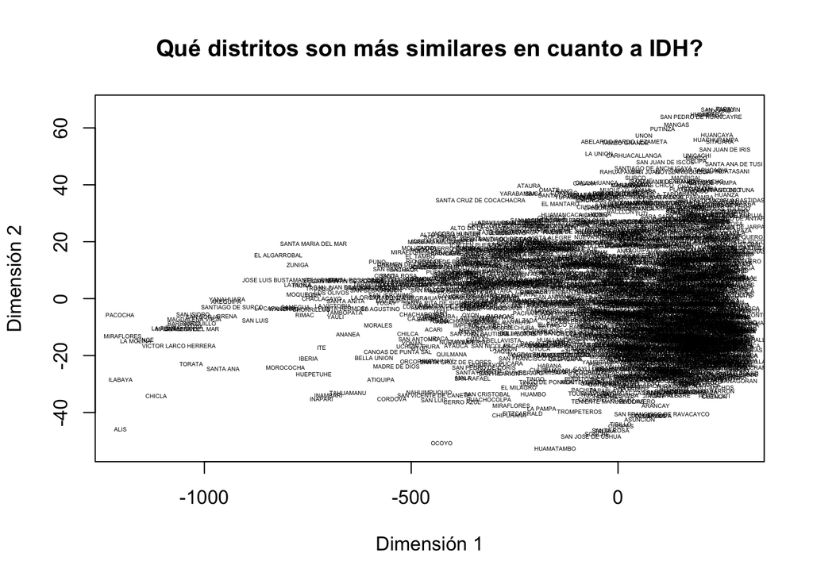

```r
labelsMap=idh_elec$dist
dimension1 <- resultado$points[,1] # coordenada
dimension2 <- resultado$points[,2] # coordenada
cols=c('red','blue')
plot(dimension1, dimension2, xlab="Dimensión 1", ylab="Dimensión 2",
  main="Qué distritos son más similares en cuanto a IDH?",  type="n")
text(dimension1, dimension2,
     labels = labelsMap,
     cex=.3)
```

Hay una gran cantidad de distritos hacia la derecha, pero nótese que hay varios distritos de Lima hacia la izquierda que se alejan de los demas.

Creemos la variable que nos indique donde ganó PPK, para ver si PPK tiene alguna presencia más notoria en alguno de estos distritos:

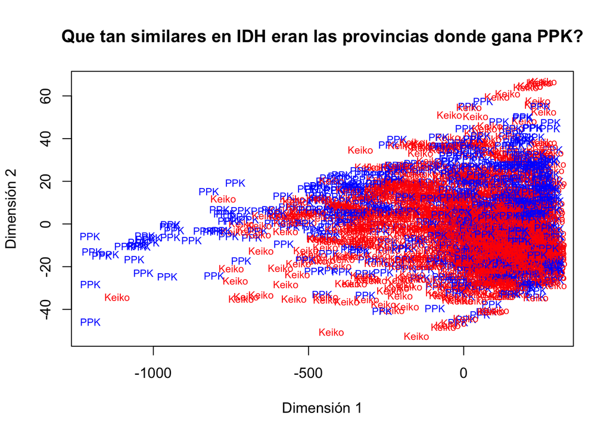

```r
idh_elec$ganappk=as.factor(ifelse(idh_elec$PPK>idh_elec$FP,1,0))
levels(idh_elec$ganappk)=c('Keiko','PPK')
labelsMap=idh_elec$ganappk
dimension1 <- resultado$points[,1]
dimension2 <- resultado$points[,2]
cols=c('red','blue')
plot(dimension1, dimension2, xlab="Dimensión 1", ylab="Dimensión 2",
  main="Que tan similares en IDH eran las provincias donde gana PPK?",  type="n")
text(dimension1, dimension2,
     labels = labelsMap,
     cex=.7,col=cols[labelsMap])
```

Vemos que PPK es quien se posiciona mejor en ese grupo de distritos limeños.

## Agrupando unidades de estudio

En el ejercicio anterior no encontramos grupos, sino coordenadas para hacer un mapa. Pero tenemos además maneras crear grupos, lo que hacemos mediante la identificación de conglomerados o clusters.

La técnica puede partir desde la matriz de distancias **d** antes calculada. Para de ahí aplicar:

```r
resultado=hclust(d)
```

Ya tenemos los clusters. Para visualizar lo que salió usamos el dendograma, el cual nos da una idea de la cantidad de clusters en que podriamos dividir a nuestros distritos:

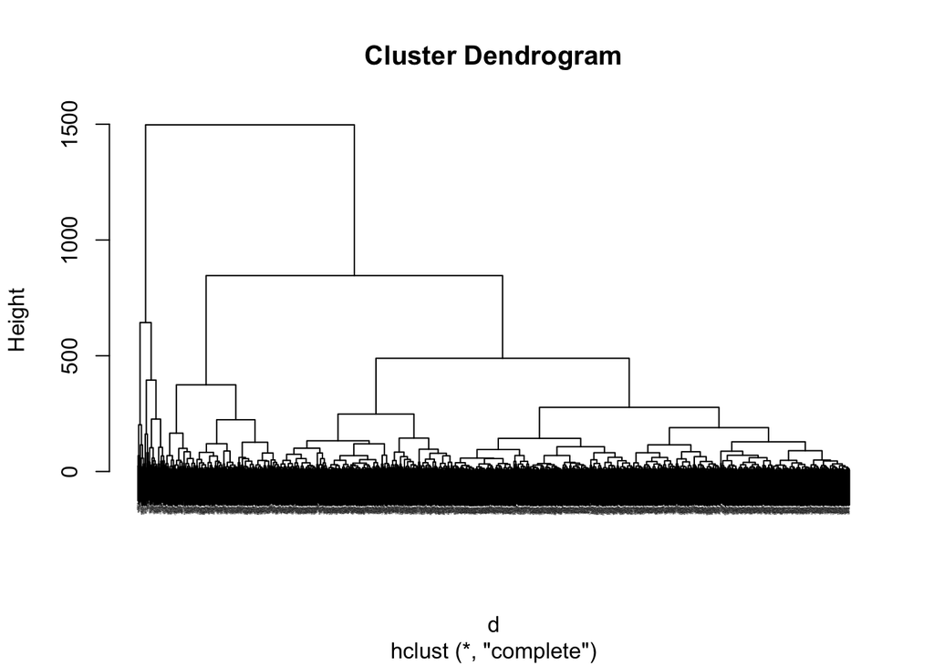

```r
plot(resultado,cex=0.1)
```

La técnica asignará un distrito a un cluster particular, pero nosotros debemos indicar cuántos queremos. Por ejemplo, si quisieramos tres, el dendograma anterior se mostraría así:

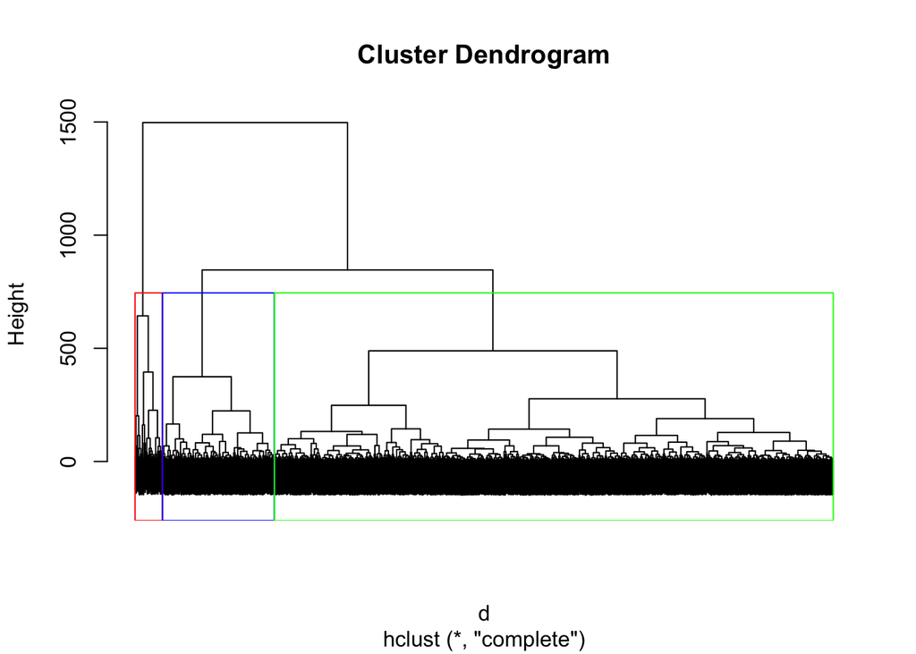

```r
plot(resultado, cex = 0.6,labels=FALSE)
rect.hclust(resultado, k = 3, border = c('red','blue','green'))
```

Si estamos de acuerdo creemos esa columna adicional en la data original:

```r
clusterColumn <- as.data.frame(cutree(resultado, k = 3))
head(clusterColumn)
```

```
##       cutree(resultado, k = 3)
## 10202                        1
## 10201                        2
## 10203                        1
## 10204                        1
## 10205                        1
## 10206                        2
```

Lo *MALO* es que los clusters creado no están en la data original.

Lo que falta es **juntar* esta data con la original (idh_elec) como una columna adicional. Para juntar o *merge* dos tablas de datos, necesitamos que tengan una columna común. Recordemos que los numeros de fila de arriba son los ubigeos del distrito; esa sería la columna común:

```r
# aqui la creamos:
clusterColumn$ubiDis=as.integer(row.names(clusterColumn))
head(clusterColumn)
```

```
##       cutree(resultado, k = 3) ubiDis
## 10202                        1  10202
## 10201                        2  10201
## 10203                        1  10203
## 10204                        1  10204
## 10205                        1  10205
## 10206                        2  10206
```

El nombre con la información del cluster es muy largo, y ya podemos borrar el ubigeo como nombre de fila:

```r
names(clusterColumn)[1]='cluster'
row.names(clusterColumn)=NULL # borrar el ubigeo como nombre de fila
head(clusterColumn)
```

```
##   cluster ubiDis
## 1       1  10202
## 2       2  10201
## 3       1  10203
## 4       1  10204
## 5       1  10205
## 6       2  10206
```

Hagamos ahora el merge:

```r
idh_elec=merge(idh_elec,clusterColumn)
```

Los clusters creados tiene un numero, pero ese numero no representa necesariamente un orden, verifiquemos:

```r
names(idh_elec)
```

```
##  [1] "ubiDis"     "ubiReg"     "ubiProv"    "depa"       "prov"
##  [6] "dist"       "pobla"      "idh"        "esperanza"  "secundaria"
## [11] "tiempoedu"  "percapitaf" "PPK"        "FP"         "ganappk"
## [16] "cluster"
```

```r
aggregate(cbind(esperanza,secundaria,tiempoedu,percapitaf) ~ cluster, data=idh_elec,FUN=median)
```

```
##   cluster esperanza secundaria tiempoedu percapitaf
## 1       1     72.60     38.160     5.990     263.50
## 2       2     75.97     66.525     9.405     719.25
## 3       3     78.79     80.085    11.090    1145.05
```

Vemos que afortunadamente los numeros sí indican algun orden entre los grupos.

Aprovechemos que cada cluster representa un distrito para graficarlo en un mapa

Traigamos el mapa por distritos:

```r
library(rgdal)
```

```r
subfolder='mapa'
fileName='DISTRITO_16_03_2015.shp'
fileToRead=file.path(folder,subfolder,fileName)
PeruMap <- readOGR(fileToRead,stringsAsFactors=F)
```

La data de IDH hay que juntarla con la data del mapa. Veamos que data tiene el mapa distrital:

```r
str(PeruMap@data)
```

```
## 'data.frame':    1853 obs. of  6 variables:
##  $ IDDPTO  : chr  "10" "10" "25" "25" ...
##  $ NOMBDEP : chr  "HUANUCO" "HUANUCO" "UCAYALI" "UCAYALI" ...
##  $ IDPROV  : chr  "1009" "1009" "2503" "2503" ...
##  $ NOMBPROV: chr  "PUERTO INCA" "PUERTO INCA" "PADRE ABAD" "PADRE ABAD" ...
##  $ IDDIST  : chr  "100902" "100904" "250305" "250302" ...
##  $ NOMBDIST: chr  "CODO DEL POZUZO" "TOURNAVISTA" "ALEXANDER VON HUMBOLDT" "IRAZOLA" ...
```

La variable IDDIST es la misma que ubiDis, pero necesita ser transformada al mismo tipo (ubiDis es entero):

```r
PeruMap@data$IDDIST=as.integer(PeruMap@data$IDDIST)
```

Así traemos la data de IDH hacia el mapa:

```r
PeruMap=merge(PeruMap,idh_elec,by.x="IDDIST",by.y="ubiDis", all.x=T)
```

Asi lo gráficamos:

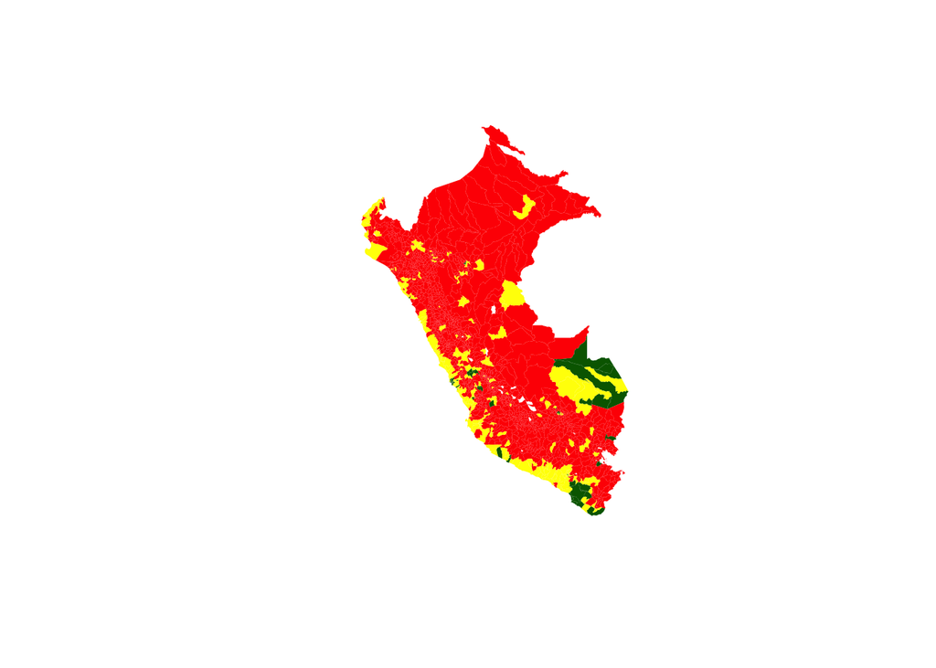

```r
colors=c('red', 'yellow','darkgreen') # colores ascendentes?
plot(PeruMap,border=F, col=colors[PeruMap@data$cluster])
```

Podemos subsetear al mapa; y saldrá un mapa enfocado en esa zona:

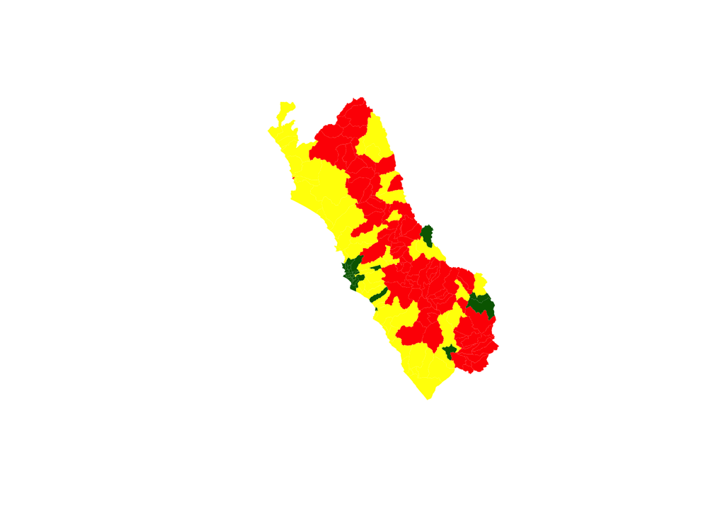

```r
LIMA=PeruMap[PeruMap@data$NOMBDEP=="LIMA",]
plot(LIMA,
     border=F, col=colors[LIMA@data$cluster])
```

## Buscando explicaciones

Si quisieramos saber cómo están relacionados los resultados electorales con el idh, necesitamos hacer una regresión. Primero, creemos un subconjunto:

```r
test=PeruMap@data[,c('ganappk','esperanza','secundaria','tiempoedu','percapitaf')]
aggregate(cbind(esperanza,secundaria,tiempoedu,percapitaf) ~ ganappk, data=test,FUN=mean)
```

```
##   ganappk esperanza secundaria tiempoedu percapitaf
## 1   Keiko  73.26403   43.87029  6.775873   386.2901
## 2     PPK  71.96195   47.73951  6.882518   399.6531
```

Exploremos ese subconjunto:

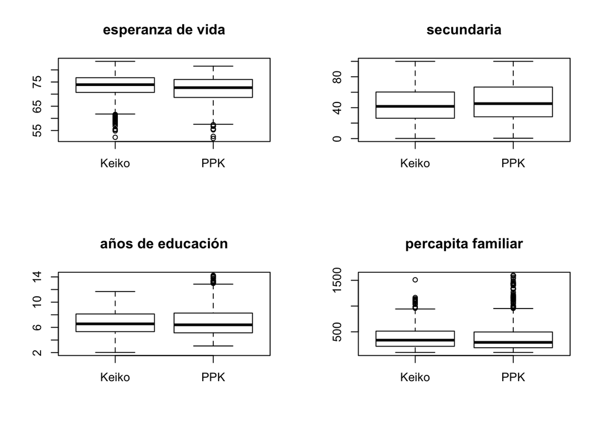

```r
par(mfrow=c(2,2))
boxplot(esperanza ~ ganappk, data=test,main='esperanza de vida')
boxplot(secundaria ~ ganappk, data=test,main='secundaria')
boxplot(tiempoedu ~ ganappk, data=test,main='años de educación')
boxplot(percapitaf ~ ganappk, data=test,main='percapita familiar')
```

Aqui calculamos es relación multivariada:

```r
testLogit <- glm(ganappk ~ .,
                 data = test,
                 family = "binomial")

summary(testLogit)
```

```
##
## Call:
## glm(formula = ganappk ~ ., family = "binomial", data = test)
##
## Deviance Residuals:
##    Min      1Q  Median      3Q     Max
## -1.666  -1.080  -0.904   1.199   1.655
##
## Coefficients:
##               Estimate Std. Error z value Pr(>|z|)
## (Intercept)  3.7432039  0.6927416   5.403 6.54e-08 ***
## esperanza   -0.0558598  0.0096419  -5.793 6.90e-09 ***
## secundaria   0.0140213  0.0032690   4.289 1.79e-05 ***
## tiempoedu   -0.1062897  0.0496310  -2.142   0.0322 *
## percapitaf   0.0005724  0.0003128   1.830   0.0673 .
## ---
## Signif. codes:  0 '***' 0.001 '**' 0.01 '*' 0.05 '.' 0.1 ' ' 1
##
## (Dispersion parameter for binomial family taken to be 1)
##
##     Null deviance: 2528.8  on 1833  degrees of freedom
## Residual deviance: 2473.6  on 1829  degrees of freedom
##   (19 observations deleted due to missingness)
## AIC: 2483.6
##
## Number of Fisher Scoring iterations: 4
```

Los valores negativos indican que el aumento de esa variable disminuye la probabilidad de ganar para PPK, los positivos lo contrario. Otra manera de leerlo:

```r
exp(coef(testLogit))
```

```
## (Intercept)   esperanza  secundaria   tiempoedu  percapitaf
##  42.2330861   0.9456717   1.0141201   0.8991641   1.0005726
```

Mientres mayor a 1, mayor la probabilidad de ganar, si es menor que 1, lo opuesto.

Lo anterior ‘modelaba’ la respuesta dicotómica *quien gana*, pero si tuvieramos una variable de conteo?

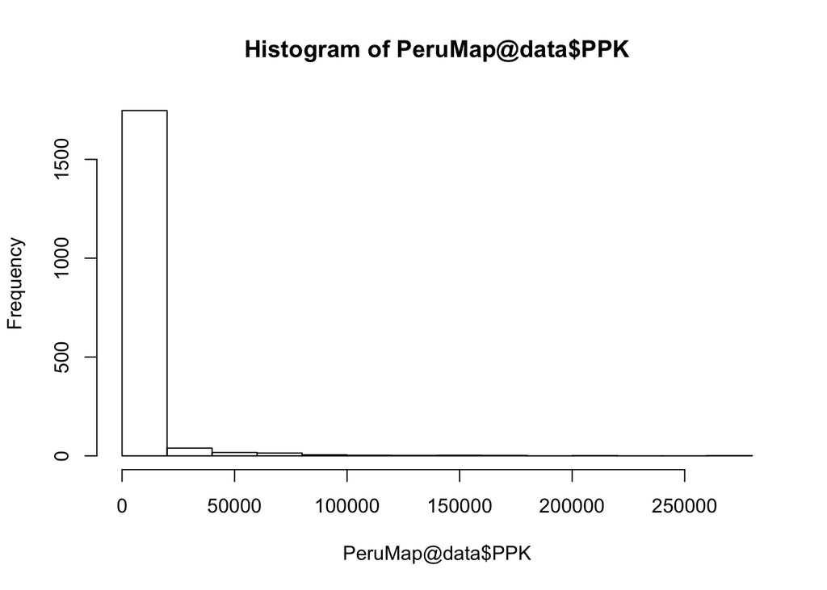

```r
hist(PeruMap@data$PPK)
```

Lo razonable sería:

```r
test2=PeruMap@data[,c('PPK','esperanza','secundaria','tiempoedu','percapitaf')]
##
library(MASS)
testCount=glm.nb(PPK ~ ., data= test2)
summary(testCount)
```

```
##
## Call:
## glm.nb(formula = PPK ~ ., data = test2, init.theta = 0.7938633075,
##     link = log)
##
## Deviance Residuals:
##     Min       1Q   Median       3Q      Max
## -3.3756  -1.1384  -0.5549   0.2034   4.2320
##
## Coefficients:
##               Estimate Std. Error z value Pr(>|z|)
## (Intercept)  6.0927490  0.3757234  16.216  < 2e-16 ***
## esperanza    0.0013744  0.0052232   0.263    0.792
## secundaria   0.0072769  0.0017782   4.092 4.27e-05 ***
## tiempoedu   -0.0367809  0.0271266  -1.356    0.175
## percapitaf   0.0036571  0.0001719  21.277  < 2e-16 ***
## ---
## Signif. codes:  0 '***' 0.001 '**' 0.01 '*' 0.05 '.' 0.1 ' ' 1
##
## (Dispersion parameter for Negative Binomial(0.7939) family taken to be 1)
##
##     Null deviance: 4265.3  on 1833  degrees of freedom
## Residual deviance: 2178.2  on 1829  degrees of freedom
##   (19 observations deleted due to missingness)
## AIC: 31887
##
## Number of Fisher Scoring iterations: 1
##
##
##               Theta:  0.7939
##           Std. Err.:  0.0226
##
##  2 x log-likelihood:  -31874.9470
```

Pero si dividiésemos el conteo de votos entre la población:

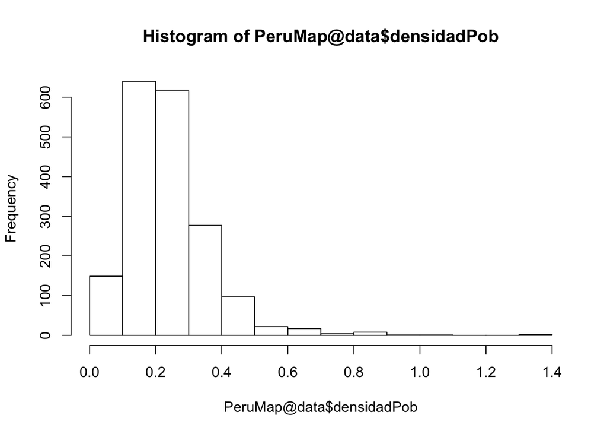

```r
PeruMap@data$densidadPob=PeruMap@data$PPK/PeruMap@data$pobla
hist(PeruMap@data$densidadPob)
```

Un modelo podría ser:

```r
test3=PeruMap@data[,c('densidadPob','esperanza','secundaria','tiempoedu','percapitaf')]
testMedida <- glm(densidadPob ~ .,
                 data = test3,
                 family = gaussian)

summary(testMedida)
```

```
##
## Call:
## glm(formula = densidadPob ~ ., family = gaussian, data = test3)
##
## Deviance Residuals:
##      Min        1Q    Median        3Q       Max
## -0.32784  -0.07237  -0.01227   0.05825   1.12578
##
## Coefficients:
##               Estimate Std. Error t value Pr(>|t|)
## (Intercept)  0.1653338  0.0380283   4.348 1.45e-05 ***
## esperanza   -0.0001776  0.0005287  -0.336   0.7370
## secundaria   0.0014663  0.0001800   8.147 6.83e-16 ***
## tiempoedu   -0.0066484  0.0027456  -2.421   0.0156 *
## percapitaf   0.0001611  0.0000174   9.258  < 2e-16 ***
## ---
## Signif. codes:  0 '***' 0.001 '**' 0.01 '*' 0.05 '.' 0.1 ' ' 1
##
## (Dispersion parameter for gaussian family taken to be 0.01291111)
##
##     Null deviance: 28.983  on 1833  degrees of freedom
## Residual deviance: 23.614  on 1829  degrees of freedom
##   (19 observations deleted due to missingness)
## AIC: -2765.6
##
## Number of Fisher Scoring iterations: 2
```

Sin embargo, dada la distribución de la densidad, el comportamiento de los residuos no se ajustará bien:

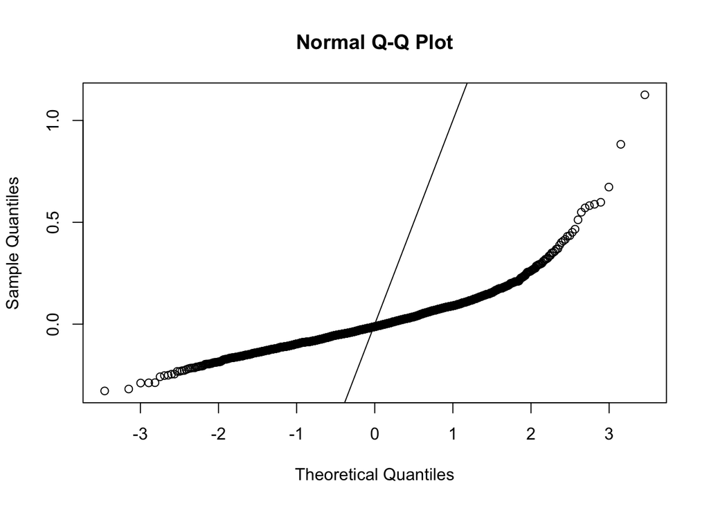

```r
qqnorm(residuals(testMedida))
abline(a=0,b=1)
```

Inicio

#### [VOLVER AL SILABO](https://inteligenciaperu.github.io/Estadistica/)